# Project 2: Cricket

Viren Halaharivi - SDS 313 UT Austin

2022-11-14

## **1.**

The dataset chosen for project two reflects the most runs by cricket batsmen across all three international formats of all time. To obtain this dataset I used the tool kaggle. The data was already conveniently a csv so I simply used read.csv to read it in. Cleaning up the data was fairly simple as well because there were no NA variables. To make the data tidy I split the span the players played into start year and end year. Obtainment and processing gave me zero problems.

```r
#read in most runs dataset
cricket = read.csv("most_runs_in_cricket.csv")
#include split of span
cricket = cricket %>% separate(Span, c("start_year", "end_year"), sep = "-")
head(cricket, n = 10)
```

```
##    X                      Player start_year end_year Mat Inns NO  Runs  HS
## 1  0        SR Tendulkar (INDIA)       1989     2013 664  782 74 34357 248
## 2  1 KC Sangakkara (Asia/ICC/SL)       2000     2015 594  666 67 28016 319
## 3  2        RT Ponting (AUS/ICC)       1995     2012 560  668 70 27483 257
## 4  3  DPMD Jayawardene (Asia/SL)       1997     2015 652  725 62 25957 374
## 5  4      JH Kallis (Afr/ICC/SA)       1995     2014 519  617 97 25534 224
## 6  5   R Dravid (Asia/ICC/INDIA)       1996     2012 509  605 72 24208 270
## 7  6             V Kohli (INDIA)       2008     2022 473  527 77 24130 254
## 8  7            BC Lara (ICC/WI)       1990     2007 430  521 38 22358 400
## 9  8     ST Jayasuriya (Asia/SL)       1989     2011 586  651 35 21032 340
## 10 9          S Chanderpaul (WI)       1994     2015 454  553 94 20988 203
##      Ave     BF    SR X100 X50 X0  X4s X6s
## 1  48.52 50817+ 67.58  100 164 34 4076 264
## 2  46.77  42086 66.56   63 153 28 3015 159
## 3  45.95  40130 68.48   71 146 39 2781 246
## 4  39.15  40100 64.73   54 136 47 2679 170
## 5  49.10  45346 56.30   62 149 33 2455 254
## 6  45.41  46564 51.98   48 146 21 2604  66
## 7  53.62  30483 79.15   71 125 33 2400 258
## 8  46.28  32839 68.08   53 111 33 2601 221
## 9  34.14  25910 81.17   42 103 53 2486 352
## 10 45.72  40150 52.27   41 125 21 2041 126
```

## **3.**

My cleaned data includes a plethora of variables on all the players. My table includes the players overall all time run rank(int), player information(character: name and teams played), start_year(character), end_year(character), total mathces played(int), total runs scored(int), number of 100s scored(int), number of 50s scored(int), number of 4s hit(int), and number of 6s hit(int). There are no NA values in my cleaned dataset.

```r
#Subset into my data
mycrick = cricket[,  c("X", "Player", "start_year", "end_year", "Mat", "Runs", "X100", "X50", "X4s", "X6s")]
mycrick
```

```
##     X                        Player start_year end_year Mat  Runs X100 X50  X4s
## 1   0          SR Tendulkar (INDIA)       1989     2013 664 34357  100 164 4076
## 2   1   KC Sangakkara (Asia/ICC/SL)       2000     2015 594 28016   63 153 3015
## 3   2          RT Ponting (AUS/ICC)       1995     2012 560 27483   71 146 2781
## 4   3    DPMD Jayawardene (Asia/SL)       1997     2015 652 25957   54 136 2679
## 5   4        JH Kallis (Afr/ICC/SA)       1995     2014 519 25534   62 149 2455
## 6   5     R Dravid (Asia/ICC/INDIA)       1996     2012 509 24208   48 146 2604
## 7   6               V Kohli (INDIA)       2008     2022 473 24130   71 125 2400
## 8   7              BC Lara (ICC/WI)       1990     2007 430 22358   53 111 2601
## 9   8       ST Jayasuriya (Asia/SL)       1989     2011 586 21032   42 103 2486
## 10  9            S Chanderpaul (WI)       1994     2015 454 20988   41 125 2041
## 11 10 Inzamam-ul-Haq (Asia/ICC/PAK)       1991     2007 499 20580   35 129 2076
## 12 11       AB de Villiers (Afr/SA)       2004     2018 420 20014   47 109 2004
## 13 12             CH Gayle (ICC/WI)       1999     2021 483 19593   42 105 2332
## 14 13            HM Amla (SA/World)       2004     2019 349 18672   55  88 2138
```

[output cut: 163 more lines]

## **4.**

The new variables created from my cleaned data include total years played(int), runs per year(int), and 100s per year(int). There are no missing values in this table. Total years played is derived by subtracting end year and start year by using the created function subtract. Runs per year is derived from the total run count divided by years played. 100s per year is derived from total centuries(X100) divided by years played.

```r
#Subtract function to find span of years played
subtract = function(x,y){
  span1 = as.numeric(x)
  span2 = as.numeric(y)
  span = span1-span2
  return (span)
}

mycrick$years_played = subtract(mycrick$end_year, mycrick$start_year)

mycrick$runs_per_year = round(mycrick$Runs/mycrick$years_played, digits = 2)
mycrick$X100s_per_year = round(mycrick$X100/mycrick$years_played, digits = 2)
newvariables = mycrick[, c("Player", "years_played", "runs_per_year", "X100s_per_year")]
newvariables
```

```
##                           Player years_played runs_per_year X100s_per_year
## 1           SR Tendulkar (INDIA)           24       1431.54           4.17
## 2    KC Sangakkara (Asia/ICC/SL)           15       1867.73           4.20
## 3           RT Ponting (AUS/ICC)           17       1616.65           4.18
## 4     DPMD Jayawardene (Asia/SL)           18       1442.06           3.00
## 5         JH Kallis (Afr/ICC/SA)           19       1343.89           3.26
## 6      R Dravid (Asia/ICC/INDIA)           16       1513.00           3.00
## 7                V Kohli (INDIA)           14       1723.57           5.07
## 8               BC Lara (ICC/WI)           17       1315.18           3.12
## 9        ST Jayasuriya (Asia/SL)           22        956.00           1.91
## 10            S Chanderpaul (WI)           21        999.43           1.95
## 11 Inzamam-ul-Haq (Asia/ICC/PAK)           16       1286.25           2.19
## 12       AB de Villiers (Afr/SA)           14       1429.57           3.36
## 13             CH Gayle (ICC/WI)           22        890.59           1.91
## 14            HM Amla (SA/World)           15       1244.80           3.67
```

[output cut: 74 more lines]

## **5.**

I created all the functions I used in my code to create univariate and bivariate plots. My first function was a histogram function, my second was a density plot, and my third was a dotplot. For my bivariate plots I created a scatterplot function and a line graph function.

```r
#Histogram function
makehist = function(var, color.want = "blue", color.fill = "lightblue", binw = 30, t, xa, ya){
  yp = ggplot()+geom_histogram(aes(x = var), color = color.want, fill = color.fill, bins = binw) + labs(title = t, x = xa, y = ya)


  print(paste("Median of Distribution: ", median(var)))
  print(paste("Mean of Distribution ", mean(var)))
  return (yp)

}

#Density Plot function
makedense = function(var, color.want = "blue",color.fill = "lightblue", t, xa, ya){
  yp = ggplot()+ geom_density(aes(x = var), color = color.want, fill = color.fill)+labs(title = t, x = xa, y = ya)
  return(yp)
}

#Dotplot Function
makedot = function(var, color.want = "blue", color.fill = "lightblue",binw, t, xa, ya){
  yp = ggplot()+geom_dotplot(aes(x = var), color = color.want, fill = color.fill, binwidth = binw)+labs(title = t, x = xa, y = ya)
  return(yp)
}

#ScatterPlot function
makescat = function(var1, var2, color.want = "black", t, xa, ya){
  yp = ggplot()+geom_point(aes(x = var1, y = var2), color = color.want)+labs(title = t, x = xa, y= ya)
  print(paste("Correlation is:", cor(var1, var2)))
  return(yp)
}

#Line graph Function
makeline = function(var1,var2, t, xa, ya){
  yp = ggplot()+geom_line(aes(x = var1, y = var2))+labs(title = t, x = xa, y = ya)
  return(yp)
}
```

```
## [1] "Median of Distribution:  15"
## [1] "Mean of Distribution  14.9090909090909"
```

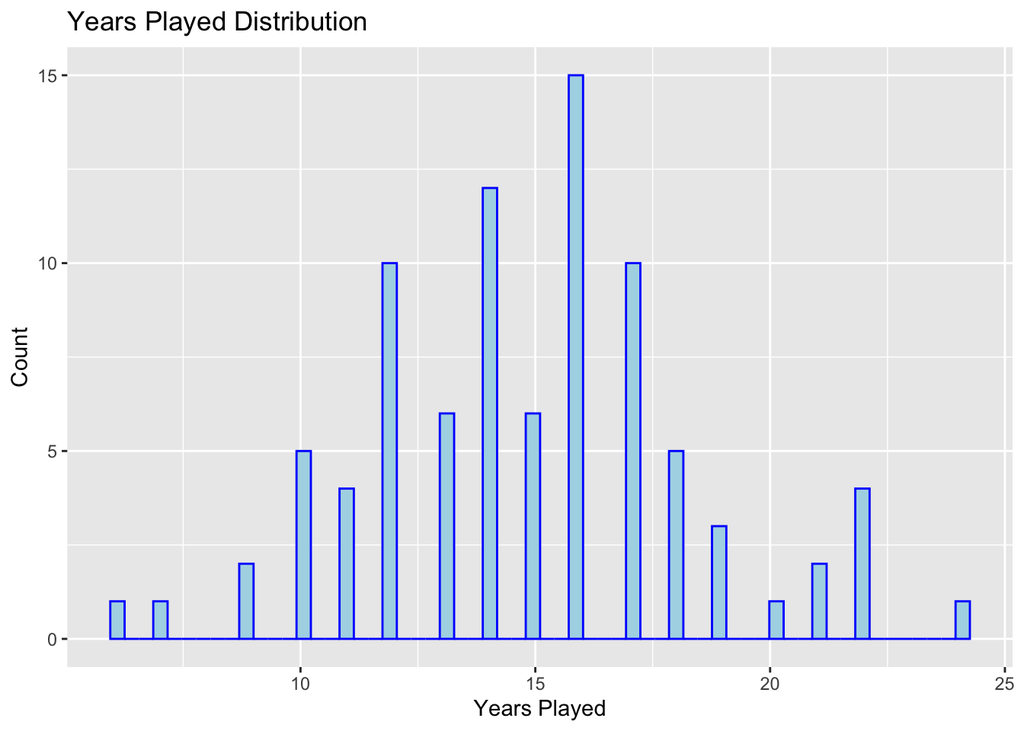

```r
makehist(mycrick$years_played, "blue", "lightblue", 60, "Years Played Distribution", "Years Played", "Count")
```

My second univariate graph is a density plot of 100s hit per year. This is a smoothed distribution along a numeric axis and shows that most of the players in the chart have around 2 centuries per year(peak is highest concentration of numeric variable.)

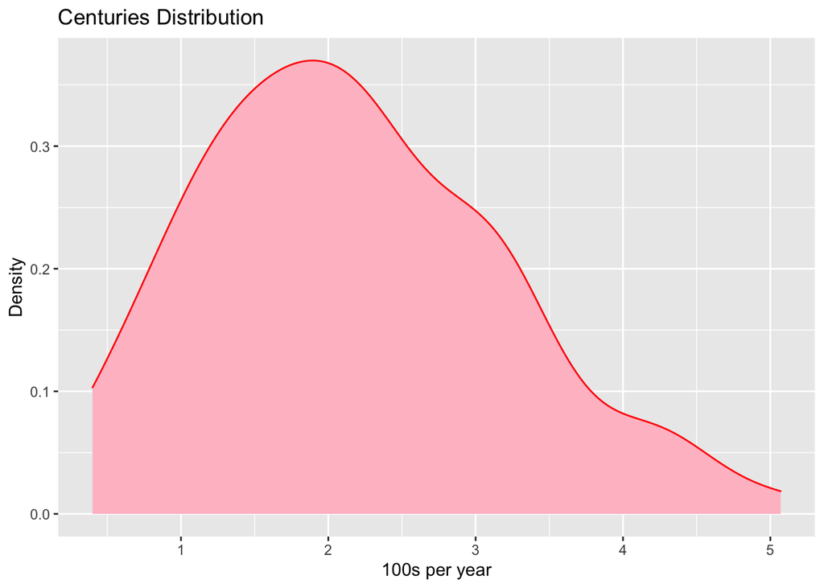

```r
makedense(mycrick$X100s_per_year, "Red","pink", "Centuries Distribution", "100s per year", "Density")
```

The dot plot for runs per year shows each observation of runs per year for each batsmen. The highest frequency of runs per year is at 700 runs per year. The dotplot also shows a slight bell shape with a slight right skew.

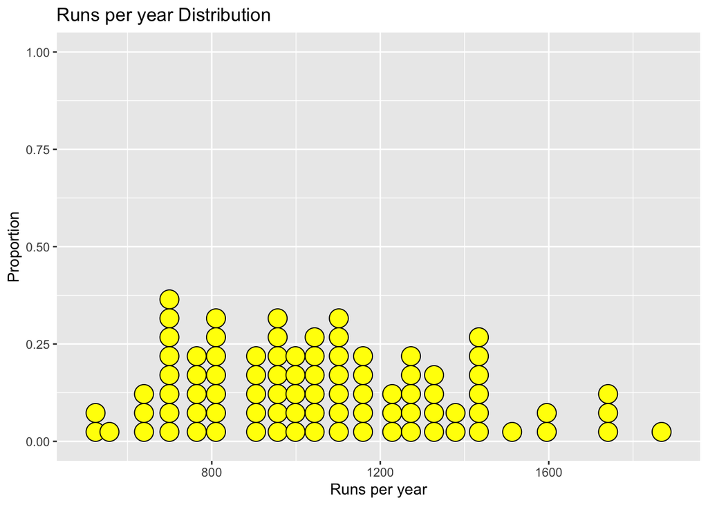

```r
makedot(mycrick$runs_per_year, "black", "yellow", 45, "Runs per year Distribution", "Runs per year", "Proportion")
```

This is a histogram of matches played for each batsmen in the dataset. The histogram is skewed to the right with a bimodal peaks. The median of the distribution is 360.5 matches played, while the mean is 365.43 matches played. Since the histogram is skewed the median is a better indicator of the actual midpoint of the data.

```
## [1] "Median of Distribution:  360.5"
## [1] "Mean of Distribution  365.431818181818"
```

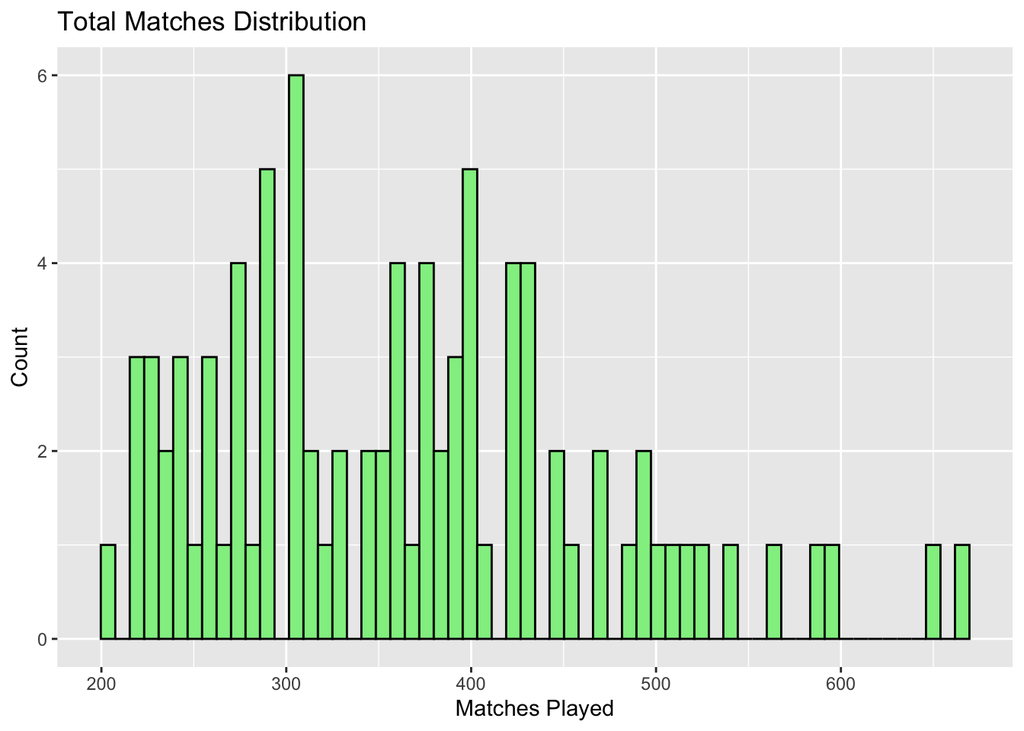

```r
makehist(mycrick$Mat, "black", "lightgreen", 60, "Total Matches Distribution", "Matches Played", "Count")
```

The last plot is another density plot on the number of 6s hit by each batsmen. In the dataset about 90 6s were hit at the highest density(peak).

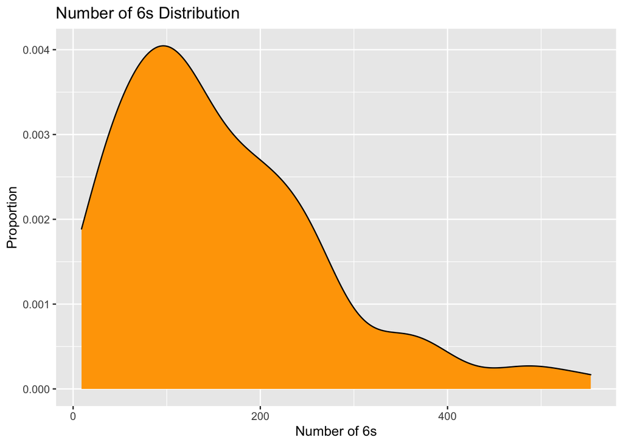

```r
makedense(mycrick$X6s, "black", "orange", "Number of 6s Distribution", "Number of 6s", "Proportion")
```

## **6.**

I created three new interesting variables using for loops. In order to discover the total proportion of runs that were boundaries(4s or 6s) I created three new variables. The code is below.

```r
for (i in 1:88){
  mycrick$propboundaries[i] = (cricket$X6s[i]+cricket$X4s[i])/cricket$Runs[i]
}
for (i in 1:88){
  mycrick$propX4[i] = cricket$X4s[i]/cricket$Runs[i]
}

for (i in 1:88){
  mycrick$propX6[i] = cricket$X6s[i]/cricket$Runs[i]
}
```

The first scatterplot shows total matches played vs total runs scored. Visually there is a positive association between both variables. The correlation of .78 indicates that there is a fairly strong correlation between total matches played and total runs scored. Initutively that makes sense(more games played=more runs scored),

```r
makescat(mycrick$Mat, mycrick$Runs, "cornflowerblue",
"Mathches Played vs Total runs", "Matches played", "Total Runs")
```

```
## [1] "Correlation is: 0.780139246123781"
```

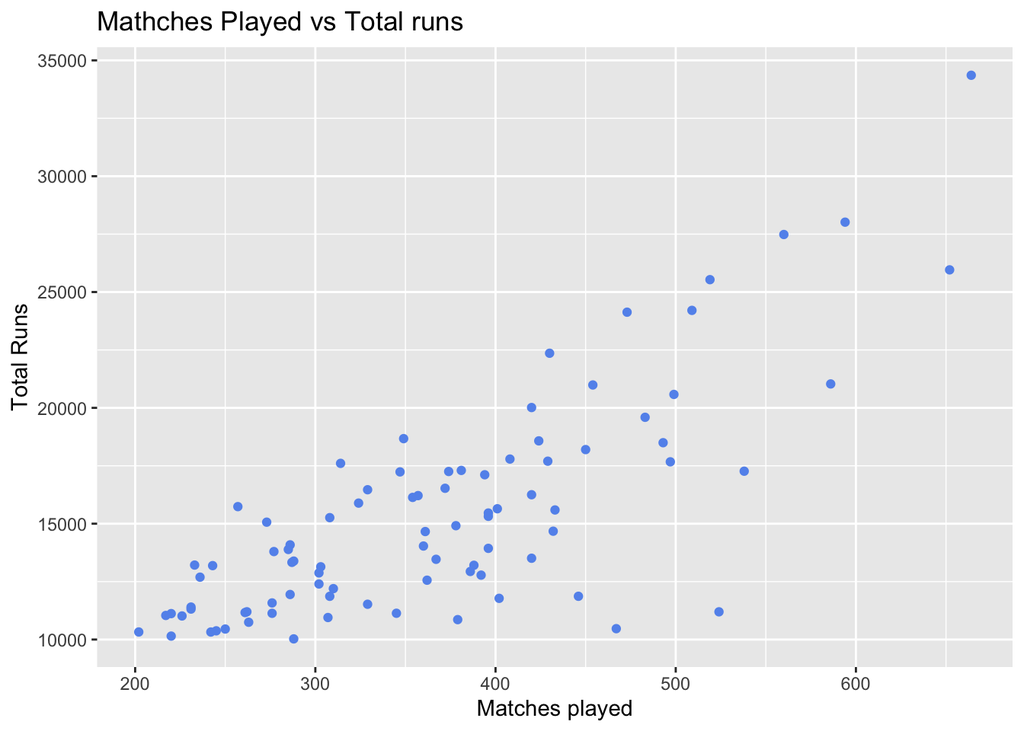

This scatterplot shows the relationship between the proportion of total runs that were 6s and the batsmens strike rate. In cricket the more runs you score per ball the higher the strike rate. The scatterplot shows a positive association and the correlation of .79 indicates that there is a fairly strong relationship between proportion of 6s and strike rate.

```r
makescat(mycrick$propX6, cricket$SR, "violet", "Proportion of 4s vs Number of 50s", "Proportion of 4s", "Number of 50s")
```

```
## [1] "Correlation is: 0.789626548461695"
```

[figure not shown]

This line chart shows the realtionship between proportion of 4s from total runs and number of 100s scored. The line chart shows a zig zag pattern however there is an interesting peak at around .119 proportion of 4s. The batsmen with the most 100s have a proportion of .11 4s in their total run count. You can’t conclude that that is a sweet spot, however it is an interesting peak.

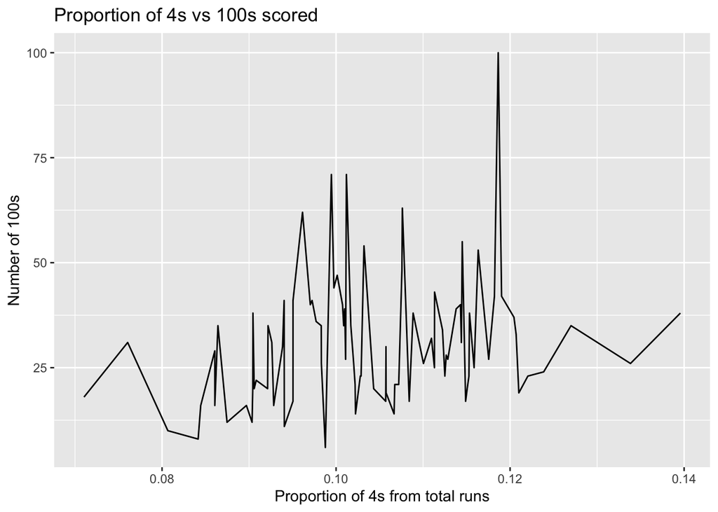

```r
makeline(mycrick$propX4, mycrick$X100, "Proportion of 4s vs 100s scored", "Proportion of 4s from total runs", "Number of 100s")
```

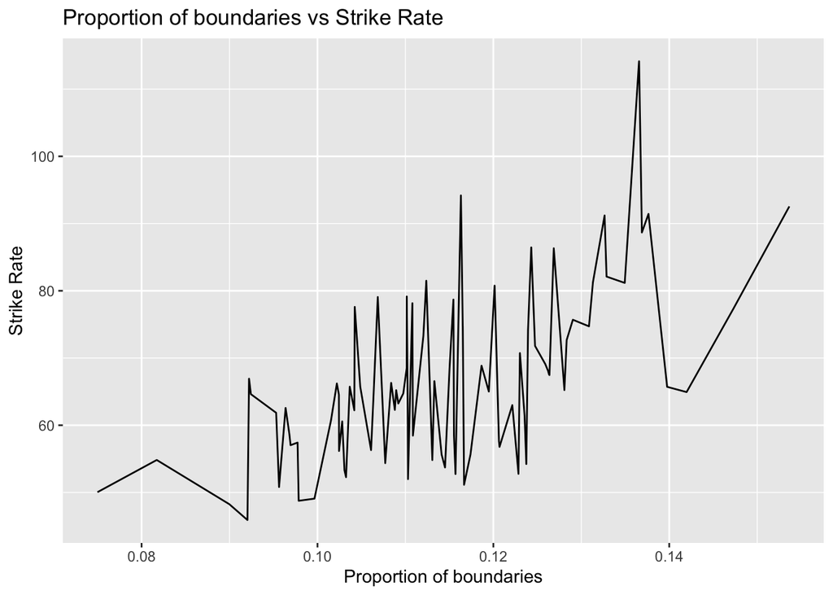

```r
makeline(mycrick$propboundaries, cricket$SR, "Proportion of boundaries vs Strike Rate", "Proportion of boundaries", "Strike Rate")
```

The last graph is the relationship between proportion of boundaries and number of 50s hit. The plot shows a scattered pattern with no visible associaiton. The correlation of -.11 tells us theres no correlation between proportion of boundaries hit and total number of 50s hit.

```r
makescat(mycrick$propboundaries, mycrick$X50, "Red", "Proportion of Boundaries Vs Number of 50s Hit", "Proportion of Boundaris", "Number of 50s")
```

```
## [1] "Correlation is: -0.111903977633802"
```

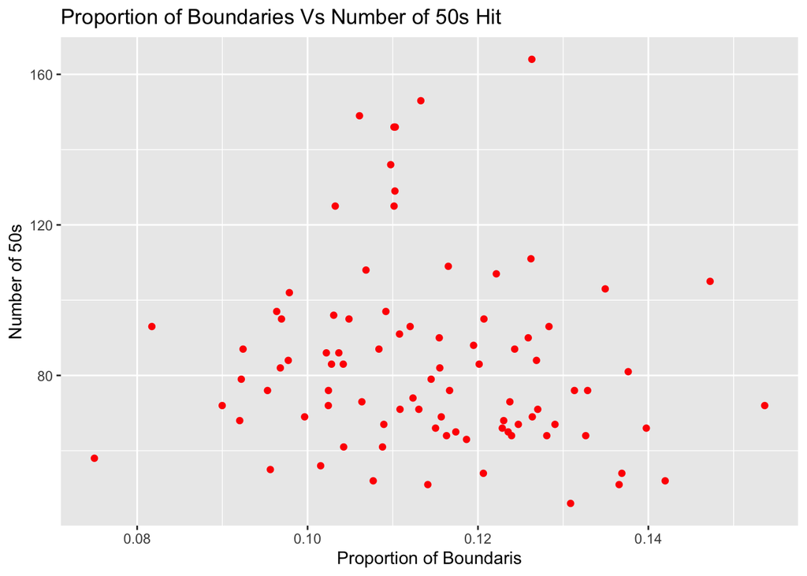

## **7.**

All requirements are clearly indicated throughout the project

## **8.**

My initial dataset had no NA values so I did not have to handle NA values throughout my experience

## **9.**

1. I had a problem creating my for loop variables because when initializing them, the new variable would not be created. I fixed the issue when I figured out that the for loop was not iterating through the whole list just the first value.
2. I had a problem initializing my histogram function, however it was a simple fix because I kept forgetting to put an xaxis aesthetic input.

#sources: https://www.kaggle.com/datasets/dheerajmukati/most-runs-in-cricket?select=most_runs_in_cricket.csv https://www.google.com/search?q=what+does+a+density+plot+show&oq=what+does+a+density+&aqs=chrome.0.0i512l2j69i57j0i512l7.3287j1j7&sourceid=chrome&ie=UTF-8

12. Github Link: https://github.com/vhalaharivi26/Project2